# NEON forecast challenge submission

Parul Patil

2025-06-14

##### Project: FREC_5174

The first thing I looked at is what variables appear to affect water temperature. I found that the strongest correlations were between air temperature and shortwave/longwave radiation. Upon looking a bit further into this, I check which variables are correlated with each other - since we dont want multicollinearity and discarded those. All the selection was just done with an exploratory analysis. No actual model selection techniques were performed. I finally chose to keep in **air_temperature**, **precipitation_flux** and **surface_downwelling_shortwave_flux_in_air**

```r
#read in the targets data
targets <- read_csv('https://data.ecoforecast.org/neon4cast-targets/aquatics/aquatics-targets.csv.gz')

# read in the sites data
aquatic_sites <- read_csv("https://raw.githubusercontent.com/eco4cast/neon4cast-targets/main/NEON_Field_Site_Metadata_20220412.csv") |>
  dplyr::filter(aquatics == 1)

lake_sites <- aquatic_sites %>%
  filter(field_site_subtype == 'Lake')

lake_sites <- unique(lake_sites$field_site_id)

# Filter the targets
targets <- targets %>%
  filter(site_id %in% lake_sites,
         variable == 'temperature')
```

```r
df_past <- neon4cast::noaa_stage3()

variables <- c("air_temperature", "precipitation_flux",
               "surface_downwelling_shortwave_flux_in_air")

# df_past |>
#   dplyr::filter(site_id %in% lake_sites,
#                 datetime >= ymd('2017-01-01')) |>
#   dplyr::collect() |> summarize(var = unique(variables))

noaa_past <- df_past |>
  dplyr::filter(site_id %in% lake_sites,
                datetime >= ymd('2017-01-01'),
                variable %in% variables) |>
  dplyr::collect()

# aggregate the past to mean values
noaa_past_mean <- noaa_past |>
  mutate(datetime = as_date(datetime)) |>
  group_by(datetime, site_id, variable) |>
  summarize(prediction = mean(prediction, na.rm = TRUE), .groups = "drop") |>
  pivot_wider(names_from = variable, values_from = prediction) |>
  # convert air temp to C
  mutate(air_temperature = air_temperature - 273.15)
```

```r
forecast_date <- Sys.Date()
noaa_date <- forecast_date - lubridate::days(2)

df_future <- neon4cast::noaa_stage2(start_date = noaa_date)

# use other variables
variables <- variables <- c("air_temperature", "precipitation_flux",
                            "surface_downwelling_shortwave_flux_in_air")

noaa_future <- df_future |>
  dplyr::filter(reference_datetime == noaa_date,
                datetime >= forecast_date,
                site_id %in% lake_sites,
                variable %in% variables) |>
  dplyr::collect()

noaa_future_daily <- noaa_future |>
  mutate(datetime = as_date(datetime)) |>
  # mean daily forecasts at each site per ensemble
  summarize(prediction = mean(prediction), .by = c("datetime", "site_id", "parameter", "variable")) |>
  pivot_wider(names_from = variable, values_from = prediction) |>
  # convert to Celsius
  mutate(air_temperature = air_temperature - 273.15) |>
  select(datetime, site_id, air_temperature, precipitation_flux,
               surface_downwelling_shortwave_flux_in_air, parameter)
```

```r
# Generate a dataframe to fit the model to
targets_df <- targets |>
  filter(variable == 'temperature') |>
  pivot_wider(names_from = 'variable', values_from = 'observation') |>
  left_join(noaa_past_mean,
            by = c("datetime","site_id"))

# Loop through each site to fit the model
temp_lm_forecast <- NULL
```

```r
split <- initial_split(targets_df, prop = 0.80, strata = site_id)

train_data <- training(split)
test_data <- testing(split)

our_recipe <- train_data |>
  recipe(temperature ~ .) |>
  # step_rm(datetime) |>
  step_naomit(air_temperature, temperature, precipitation_flux,
               surface_downwelling_shortwave_flux_in_air)
```

The next step was to select the model. I tried a variety that included regression and arima (time series based regression), along with some tree methods such as random forest and bagged trees, and mars which is a non parameteric regression which makes it flexible to model nonlinearity and interactions.

I did not evaluate this code because this will be running everyday so I just looked at it in my window and noticed that tree methods give the best rsq and rmse values. However, the forecasted temperatures did not look very convincing. There were random patterns in the ensemble members with an overall larger spread and disagreeing trends. Thus, I decided to go with the spline model which although seemed to have smaller rsq than the tree methods gave much better UQ i.e. ensembles members seemed to have some trend and be in agreement, with some spread

```r
our_model1 <- mars(mode = "regression")  |> set_engine("earth")

our_model2 <- rand_forest(mode = "regression")  |> set_engine("randomForest")

our_model3 <- bag_tree(mode = "regression")  |> set_engine("rpart")

our_model4 <- arima_reg(mode = "regression")  |> set_engine("arima")

our_model5 <- linear_reg(mode = "regression")  |> set_engine("lm")

models <- c("mars", "rf", "bagtree","arima","lm")

our_model <- list(our_model1, our_model2, our_model3, our_model4, our_model5)

test_data_df <- na.omit(test_data)

metrics <- matrix(NA, nrow = 2, ncol = length(our_model))
colnames(metrics) <- models
rownames(metrics) <- c("rmse", "rsq")

for(i in 1:length(our_model)){
  wflow <-
    workflow() |>
    add_model(our_model[[i]]) |>
    add_recipe(our_recipe)

  fit <- wflow |> fit(data = train_data)

  predictions <- predict(fit, new_data = test_data_df)
  pred_test <- bind_cols(test_data, predictions)

  multi_metric <- metric_set(rmse, rsq)

  metric_table <- pred_test |>
    multi_metric(truth = temperature, estimate = .pred)

  metrics[,i] <- metric_table$.estimate
}
```

The model i chose was mars.

```r
our_model <- our_model1 <- mars(mode = "regression")  |> set_engine("earth")

wflow <-
  workflow() |>
  add_model(our_model1) |>
  add_recipe(our_recipe)

fit <- wflow |> fit(data = train_data)

predictions <- predict(fit, new_data = test_data)
pred_test <- bind_cols(test_data, predictions)

multi_metric <- metric_set(rmse, rsq)

metric_table <- pred_test |>
  multi_metric(truth = temperature, estimate = .pred)

metric_table
```

```
## # A tibble: 2 × 3
##   .metric .estimator .estimate
##   <chr>   <chr>          <dbl>
## 1 rmse    standard       2.51
## 2 rsq     standard       0.862
```

```r
targets_future <- noaa_future_daily |>
  mutate(temperature = NA,
         doy = yday(datetime)) |>
  filter(parameter == 1) |>
  select(-parameter)

new_predictions <- predict(fit, new_data = targets_future)
```

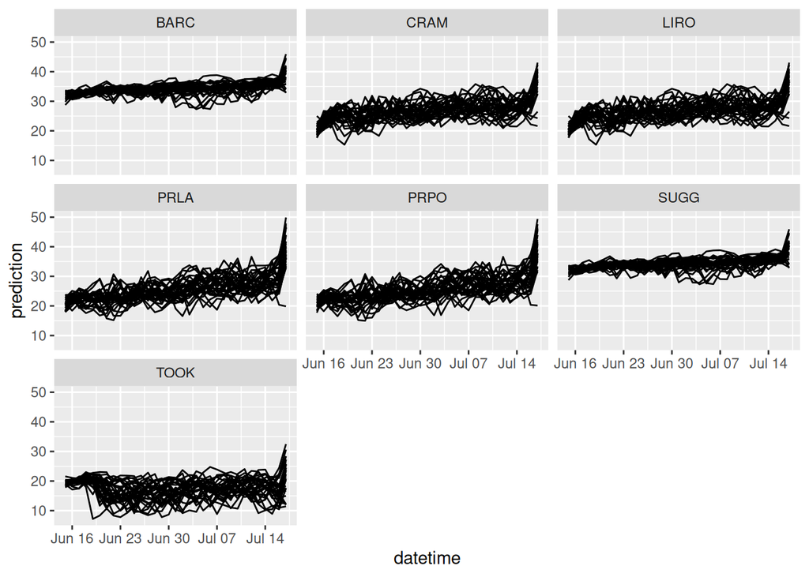

```r
targets_future <- noaa_future_daily |>
  mutate(temperature = NA,
         doy = yday(datetime))

tidymodels_forecast <- data.frame()

for(i in unique(targets_future$parameter)){
  curr_ens <- targets_future |>
    filter(parameter == i) |>
    select(-parameter)

  new_predictions <- predict(fit, new_data = curr_ens)
  curr_ens <- bind_cols(curr_ens, new_predictions) |>
    mutate(parameter = i)
  tidymodels_forecast <- bind_rows(tidymodels_forecast, curr_ens)
}

tidymodels_forecasts_EFI <- tidymodels_forecast %>%
  rename(prediction = .pred) %>%
  mutate(variable = "temperature") |>
  # For the EFI challenge we only want the forecast for future
  filter(datetime > Sys.Date()) %>%
  group_by(site_id, variable) %>%
  mutate(reference_datetime = min(datetime) - lubridate::days(1),
         family = "ensemble",
         model_id = "tidymodels_lm") %>%
  select(model_id, datetime, reference_datetime, site_id, family, parameter, variable, prediction)

tidymodels_forecasts_EFI |>
  filter(variable == "temperature") |>
  ggplot(aes(x = datetime, y = prediction, group = parameter)) +
  geom_line() +
  facet_wrap(~site_id)
```

```r
# Make forecast fit the EFI standards
# Remember to change the model_id when you make changes to the model structure!
my_model_id <- 'parulpatil_frec'

temp_lm_forecast_EFI <- tidymodels_forecasts_EFI
```

```r
# Write the forecast to file
theme <- 'aquatics'
date <- temp_lm_forecast_EFI$reference_datetime[1]
forecast_name_1 <- paste0(temp_lm_forecast_EFI$model_id[1], ".csv")
forecast_file_1 <- paste(theme, date, forecast_name_1, sep = '-')
forecast_file_1
```

```
## [1] "aquatics-2025-06-14-tidymodels_lm.csv"
```

```r
if (!dir.exists('Forecasts')) {
  dir.create('Forecasts')
}

write_csv(temp_lm_forecast_EFI, file.path('Forecasts',forecast_file_1))

neon4cast::forecast_output_validator(file.path('Forecasts',forecast_file_1))
```

```
## Forecasts/aquatics-2025-06-14-tidymodels_lm.csv
```

```
## ✔ file has model_id column
## ✔ forecasted variables found correct variable + prediction column
## ✔ temperature is a valid variable name
## ✔ file has correct family and parameter columns
## ✔ file has site_id column
## ✔ file has datetime column
## ✔ file has correct datetime column
```

```
## ✔ file has reference_datetime column
## Forecast format is valid
```

```
## [1] TRUE
```

```r
## # can uses the neon4cast::forecast_output_validator() to check the forecast is in the right format

# UNCOMMMENT THIS WHEN YOU ARE READY TO SUBMIT
neon4cast::submit(forecast_file = file.path('Forecasts', forecast_file_1),
                  ask = FALSE) # if ask = T (default), it will produce a pop-up box asking if you want to submit
```

```
## validating that file matches required standard
```

```
## Forecasts/aquatics-2025-06-14-tidymodels_lm.csv
```

```
## ✔ file has model_id column
## ✔ forecasted variables found correct variable + prediction column
## ✔ temperature is a valid variable name
## ✔ file has correct family and parameter columns
## ✔ file has site_id column
## ✔ file has datetime column
## ✔ file has correct datetime column
```

```
## ✔ file has reference_datetime column
## Forecast format is valid
##
## Thank you for submitting!
```

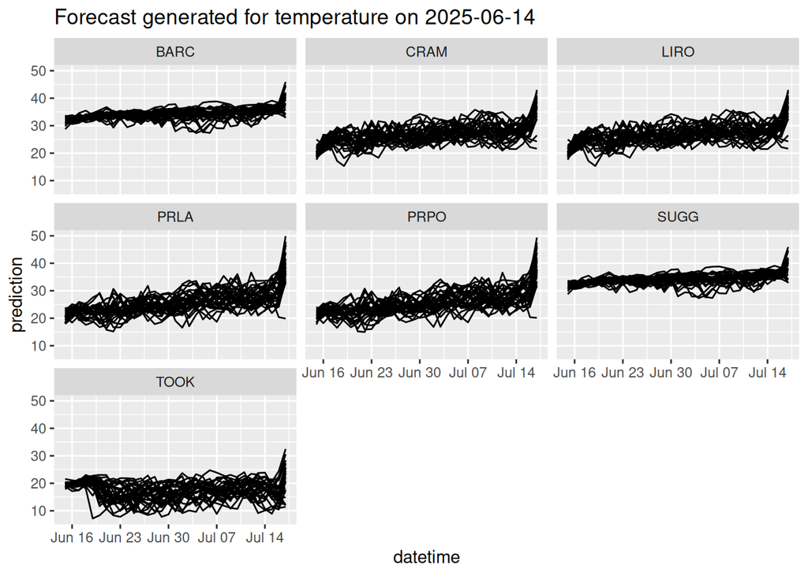

```r
temp_lm_forecast_EFI |>
  ggplot(aes(x=datetime, y=prediction, group = parameter)) +
  geom_line() +
  facet_wrap(~site_id) +
  labs(title = paste0('Forecast generated for ', temp_lm_forecast_EFI$variable[1], ' on ', temp_lm_forecast_EFI$reference_datetime[1]))
```